# Data import and manipulation in poppr version 2.8.7

# Appendix

## Manipulating Graphics

*Poppr* utilizes *ggplot2* to produce many of its graphs. One advantage it gives the user is the ability to manipulate these graphs. With base R graphs, the only manipulation that can be performed is by adding elements to the graph. It is a static image. The ggplot graphs are actually represented as objects in your R environment. We can use the function `last_plot()` from *ggplot2* to be able to grab the plot that was plotted last in our window. Let’s illustrate this using a MLG bar graph from the Aeut data set.

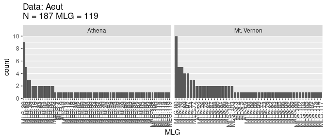

```r
library("poppr")
library("ggplot2")
data(Aeut)
Aeut.tab <- mlg.table(Aeut)
```

```r
p <- last_plot()
```

We’ve captured our plot using `last_plot()` and now we can manipulate it. One common need is to change the title. We can easily do that with the function `ggtitle()`. Let“s say we wanted to label it”*Aphanomyces euteiches* multilocus genotype distribution". We would use `ggtitle(Aphanomyces euteiches multilocus genotype distribution)`. Unfortunately, we need italics for a latin binomial. One way to acheive this is by using the `expression()` function and declaring which text needs to be italicized.

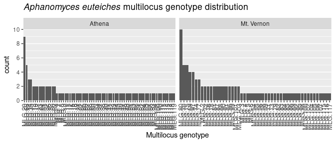

```r
myTitle <- expression(paste(italic("Aphanomyces euteiches"),
                      " multilocus genotype distribution"))
(pt <- p +
   ggtitle(myTitle) +
   xlab("Multilocus genotype")) # We can label the x axis, too
```

Let"s say we wanted to remove the grey background. We could use the `theme()` function to do this, or we could use a theme already implemented in ggplot2 called `theme_bw()`.

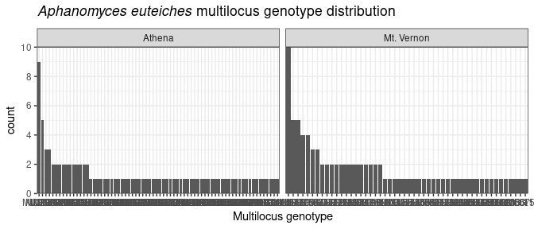

```r
(ptt <- pt + theme_bw())
```

Uh-oh. The x axis labels are now horizontal when they should be vertical. Since it"s the overall distribution we’re interested in, we don’t really need them anyways. We can remove them with `axis.text.x` and `axis.ticks.x` (we’ll also remove the x axis gridlines because they’re ugly).

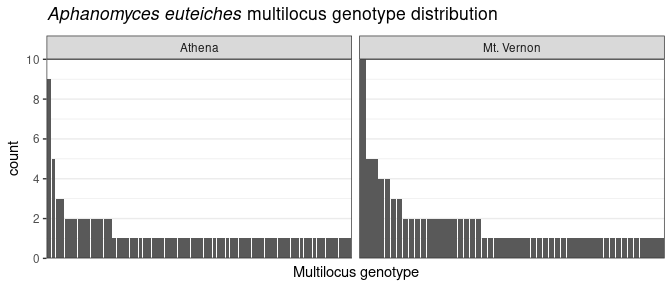

```r
(ptta <- ptt + theme(axis.text.x = element_blank()) +
  theme(axis.ticks.x = element_blank()) +
  theme(panel.grid.major.x = element_blank()))
```

And, if for some bizarre reason, you liked the color gradient in *poppr* version 1, you can get that back by adding the *fill* aesthetic:

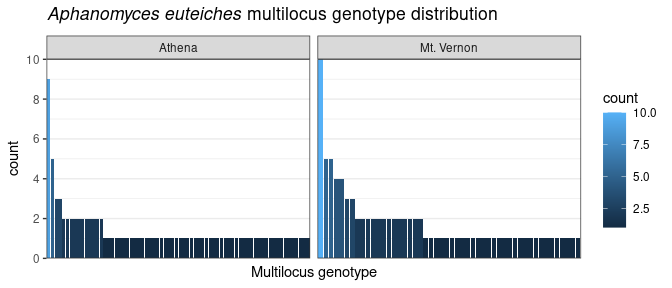

```r
(ptttaf <- ptta + aes(fill = count))
```

This allows you to produce publication quality graphs directly in R. Please see Hadley Wickham“s *ggplot2* package for more details (Wickham 2009). Note that if you don”t like using *ggplot2*, you can access the data in the ggplot2 object and plot the data yourself:

```r
head(p$data)
```

```
## # A tibble: 6 x 4
##   Population MLG    count order
##   <fct>      <chr>  <int> <fct>
## 1 Athena     MLG.20     9 1
## 2 Athena     MLG.66     5 2
## 3 Athena     MLG.14     3 3
## 4 Athena     MLG.35     3 4
## 5 Athena     MLG.13     2 5
## 6 Athena     MLG.16     2 6
```

## Exporting Graphics

R has the ability to produce nice graphics from most any type of data, but to get these graphics into a report, presentation, or manuscript can be a bit challenging. It"s no secret that the R Documentation pages are a little difficult to interpret, so I will give the reader here a short example on how to export graphics from R. Note that any code here that will produce images will also be present in other places in this vignette. The default installation of the R GUI is quite minimal, and for an easy way to manage your plots and code, I strongly encourage the user to use Rstudio https://rstudio.com/.

### Basics

Before you export graphics, you have to ask yourself what they will be used for. If you want to use the graphic for a website, you might want to opt for a low-resolution image so that it can load quickly. With printing, you"ll want to make sure that you have a scalable or at least a very high resolution image. Here, I will give some general guidelines for graphics (note that these are merely suggestions, not defined rules).

- **What you see is not always what you get** I have often seen presentations where the colors were too light or posters with painfully pixellated graphs. Think about what you are going to be using a graphic for and how it will appear to the intended audience given the media type.
- **$\geq$ 300 dpi unless its for a web page** For any sort of printed material that requires a raster based image, 300dpi (dots per inch) is the absolute minimum resolution you should use. For simple black and white line images, 1200dpi is better. This will leave you with crisp, professional looking images.
- **If possible, save to SVG, then rasterize** Raster images (bmp, png, jpg, etc…) are based off of the number of pixels or dots per inch it takes to render the image. This means that the raster image is more or less a very fine mosaic. Vector images (SVG) are built upon several interconnected polygons, arcs, and lines that scale relative to one another to create your graphic. With vector graphics, you can produce a plot and scale it to the size of a building if you wanted to. When you save to an SVG file first, you can also manipulate it in programs such as Adobe Illustrator or Inkscape.
- **Before saving, make sure the units and dimensions are correct** Unless you really wanted to save a graph that"s over 6 feet wide.

### Image Editors

Often times, fine details such as labels on networks need to be tweaked by hand. Luckily, there are a wide variety of programs that can help you do that. Here is a short list of image editors (both free and for a price) that you can use to edit your graphics.

- Bitmap based editors (for jpeg, bmp, png, etc…)
  - **The GIMP** Free, cross-platform. https://www.gimp.org
  - **Paint.net** Free, Windows only. https://www.getpaint.net
  - **Adobe Photoshop** Pricey, Windows and Mac. https://www.adobe.com/products/photoshop.html
- Scalable Vector Graphics based editors (for svg, pdf)
  - **Inkscape** Free, cross-platform https://inkscape.org
  - **Adobe Illustrator** Pricey, Windows and Mac. https://www.adobe.com/products/illustrator.html

### Exporting ggplot2 graphics

*ggplot2* is a fantastic package that *poppr* uses to produce graphs for the `mlg.table()`, `poppr()`, and `ia()` functions. Saving a plot with *ggplot2* is performed with one command after your plot has rendered:

```r
data(nancycats) # Load the data set.
poppr(nancycats, sample = 999) # Produce a single plot.
ggsave("nancycats.pdf")
```

Note that you can name the file anything, and `ggsave` will save it in that format for you. The details are in the documentation and you can access it by typing `help(ggsave)` in your R console. The important things to note are that you can set a `width`, `height`, and `unit`. The only downside to this function is that you can only save one plot at a time. If you want to be able to save multiple plots, read on to the next section.

### Exporting any graphics

Some of the functions that *poppr* offers will give you multiple plots, and if you want to save them all, using `ggsave` will require a lot of tedious typing and clicking. Luckily, R has Functions that will save any plot you generate in nearly any image format you want. You can save in raster images such as png, bpm, and jpeg. You can also save in vector based images such as svg, pdf, and postscript. The important thing to remember is that when you are saving in a raster format, the default units of measurement are “pixels”, but you can change that by specifying your unit of choice and a resolution.

For raster images and svg files, you can only save your plots in multiple files, but pdf and postscript plots can be saved in one file as multiple pages. All of these functions have the same basic form. You call the function to specify the file type you want (eg. `pdf(myfile.pdf)`), create any graphs that you want to create, and then make sure to close the session with the function `dev.off()`. Let"s give an example saving to pdf and png files.

```r
data(nancycats)

png("nancy_pair%02d.png", width = 14, height = 14, units = "in", res = 300)
poppairs <- lapply(seppop(nancycats), pair.ia, limits = c(-0.25, 1))
dev.off()
```

```r
pdf("nancy_pair.png", width = 14, height = 14, compress = FALSE)
poppairs <- lapply(seppop(nancycats), pair.ia, limits = c(-0.25, 1))
dev.off()
```

Remember, it is important not to forget to type `dev.off()` when you are done making graphs. Note that I did not have to specify a resolution for this image since it is based off of vector graphics.

# References

Agapow, Paul-Michael, and Austin Burt. 2001. “Indices of Multilocus Linkage Disequilibrium.” *Molecular Ecology Notes* 1 (1-2): 101–2. https://doi.org/10.1046/j.1471-8278.2000.00014.x.

Brown, A.H. D., M.W. Feldman, and E. Nevo. 1980. “MULTILOCUS Structure of Natural Populations of *Hordeum Spontaneum*.” *Genetics* 96 (2): 523–36.

Bruvo, Ruzica, Nicolaas K. Michiels, Thomas G. D’Souza, and Hinrich Schulenburg. 2004. “A Simple Method for the Calculation of Microsatellite Genotype Distances Irrespective of Ploidy Level.” *Molecular Ecology* 13 (7): 2101–6. https://doi.org/10.1111/j.1365-294X.2004.02209.x.

Everhart, Sydney, and Harald Scherm. 2015. “Fine-Scale Genetic Structure of *Monilinia Fructicola* During Brown Rot Epidemics Within Individual Peach Tree Canopies.” *Phytopathology* 105 (4): 542–49. https://doi.org/10.1094/PHYTO-03-14-0088-R.

Goss, Erica M, Meg Larsen, Gary A Chastagner, Donald R Givens, and Niklaus J Grünwald. 2009. “Population Genetic Analysis Infers Migration Pathways of Phytophthora Ramorum in Us Nurseries.” *PLoS Pathog* 5 (9): e1000583.

Goss, Erica M., Javier F. Tabima, David E. L. Cooke, Silvia Restrepo, William E. Fry, Gregory A. Forbes, Valerie J. Fieland, Martha Cardenas, and Niklaus J. Grünwald. 2014. “The Irish Potato Famine Pathogen Phytophthora Infestans Originated in Central Mexico Rather Than the Andes.” *Proceedings of the National Academy of Sciences* 111 (24): 8791–6. https://doi.org/10.1073/pnas.1401884111.

Grünwald, Niklaus J., Stephen B. Goodwin, Michael G. Milgroom, and William E. Fry. 2003. “Analysis of Genotypic Diversity Data for Populations of Microorganisms.” *Phytopathology* 93 (6): 738–46. https://doi.org/10.1094/PHYTO.2003.93.6.738.

Grünwald, N. J., and G. Hoheisel. 2006. “Hierarchical Analysis of Diversity, Selfing, and Genetic Differentiation in Populations of the Oomycete *Aphanomyces Euteiches*.” *Phytopathology* 96 (10): 1134–41.

Heck, Kenneth L.Jr., Gerald van Belle, and Daniel Simberloff. 1975. “Explicit Calculation of the Rarefaction Diversity Measurement and the Determination of Sufficient Sample Size.” *Ecology* 56 (6): pp. 1459–61.

Hurlbert, S H. 1971. “The Nonconcept of Species Diversity: A Critique and Alternative Parameters.” *Ecology* 52 (4): 577–86.

Jombart, Thibaut. 2008. “Adegenet: A R Package for the Multivariate Analysis of Genetic Markers.” *Bioinformatics* 24 (11): 1403–5. https://doi.org/10.1093/bioinformatics/btn129.

Kamvar, Zhian N, Jonah C Brooks, and Niklaus J Grünwald. 2015. “Novel R tools for analysis of genome-wide population genetic data with emphasis on clonality.” *Frontiers in Genetics* 6: 208. https://doi.org/10.3389/fgene.2015.00208.

Kamvar, Zhian N., Javier F. Tabima, and Niklaus J. Grünwald. 2014. “*Poppr*: An R Package for Genetic Analysis of Populations with Clonal, Partially Clonal, and/or Sexual Reproduction.” *PeerJ* 2 (March): e281. https://doi.org/10.7717/peerj.281.

Kamvar, ZN, MM Larsen, AM Kanaskie, EM Hansen, and NJ Grünwald. 2015. “Spatial and Temporal Analysis of Populations of the Sudden Oak Death Pathogen in Oregon Forests.” *Phytopathology*, PHYTO–12.

Ludwig, J. A., and J. F. Reynolds. 1988. *Statistical Ecology. A Primer on Methods and Computing*. New York USA: John Wiley; Sons.

Nei, Masatoshi. 1978. “ESTIMATION of Average Heterozygosity and Genetic Distance from a Small Number of Individuals.” *Genetics* 89 (3): 583–90.

Oksanen, Jari, F. Guillaume Blanchet, Roeland Kindt, Pierre Legendre, Peter R. Minchin, R. B. O’Hara, Gavin L. Simpson, Peter Solymos, M. Henry H. Stevens, and Helene Wagner. 2012. *Vegan: Community Ecology Package*. https://CRAN.R-project.org/package=vegan.

Peakall, Rod, and Peter E. Smouse. 2012. “GenAlEx 6.5: Genetic Analysis in Excel. Population Genetic Software for Teaching and Research—an Update.” *Bioinformatics* 28 (19): 2537–9. https://doi.org/10.1093/bioinformatics/bts460.

Peakall, R., and P. E. Smouse. 2006. “GenAlEx 6: Genetic Analysis in Excel. Population Genetic Software for Teaching and Research.” *Molecular Ecology Notes* 6 (1): 288–295+.

Pielou, EC. 1975. *Ecological Diversity–John Wiley & Sons*. *New York*.

Shannon, Claude Elwood. 1948. “A Mathematical Theory of Communication.” *Bell Systems Technical Journal* 27: 379–423, 623–56.

Smith, J M, N H Smith, M O’Rourke, and B G Spratt. 1993. “How Clonal Are Bacteria?” *Proceedings of the National Academy of Sciences* 90 (10): 4384–8. https://doi.org/10.1073/pnas.90.10.4384.

Stoddart, J. A., and J. F. Taylor. 1988. “Genotypic Diversity: Estimation and Prediction in Samples.” *Genetics* 118 (4): 705–11.

Wickham, Hadley. 2009. *Ggplot2: Elegant Graphics for Data Analysis*. Springer New York.

[^1]: This window sometimes appears behind your current session of R, depending on the GUI and you will have to toggle to this window
[^2]: *.CSV files are comma separated files that are easily machine readable.